# Data Preparation

Maria Pais, Mónica Araújo

2023-11-07

# 1 Data Preparation

## 1.1 Conversão do tipo de dados (Data Structure)

Conversão do tipos de dados, garantindo a consistência e adequação dos tipos de dados para análises e visualizações e facilitando operações específicas, como ordenação e filtragem.

Nota: Na conversão da data foi utilizada a adição do século ‘19’ para garantir a interpretação correta do ano.

```r
account$account_id <- as.integer(account$account_id)
account$district_id <- as.factor(account$district_id)
account$frequency <- as.factor(account$frequency)
if(!inherits(account$date, "Date")){
  account$date <- as.Date(sprintf("%s%s", "19", account$date), format="%Y%m%d")
}

#load()
str(account)
```

```
## spc_tbl_ [4,500 × 4] (S3: spec_tbl_df/tbl_df/tbl/data.frame)
##  $ account_id : int [1:4500] 576 3818 704 2378 2632 1972 1539 793 2484 1695 ...
##  $ district_id: Factor w/ 77 levels "1","2","3","4",..: 55 74 55 16 24 77 1 47 74 76 ...
##  $ frequency  : Factor w/ 3 levels "issuance after transaction",..: 2 2 2 2 2 2 1 2 2 2 ...
##  $ date       : Date[1:4500], format: "1993-01-01" "1993-01-01" ...
##  - attr(*, "spec")=
##   .. cols(
##   ..   account_id = col_double(),
##   ..   district_id = col_double(),
##   ..   frequency = col_character(),
##   ..   date = col_double()
##   .. )
##  - attr(*, "problems")=<externalptr>
```

```r
cat("\n")
```

```r
summary(account)
```

```
##    account_id     district_id                        frequency
##  Min.   :    1   1      : 554   issuance after transaction:  93
##  1st Qu.: 1183   70     : 152   monthly issuance          :4167
##  Median : 2368   74     : 135   weekly issuance           : 240
##  Mean   : 2786   54     : 128
##  3rd Qu.: 3552   64     :  92
##  Max.   :11382   72     :  88
##                  (Other):3351
##       date
##  Min.   :1993-01-01
##  1st Qu.:1993-12-27
##  Median :1996-01-02
##  Mean   :1995-08-08
##  3rd Qu.:1996-11-01
##  Max.   :1997-12-29
##
```

```r
card_dev$card_id <- as.integer(card_dev$card_id)
card_dev$disp_id <- as.integer(card_dev$disp_id)
card_dev$type <- as.factor(card_dev$type)
if(!inherits(card_dev$issued, "Date")){
  card_dev$issued <- as.Date(sprintf("%s%s", "19", card_dev$issued), format="%Y%m%d")
}
str(card_dev)
```

```
## spc_tbl_ [177 × 4] (S3: spec_tbl_df/tbl_df/tbl/data.frame)
##  $ card_id: int [1:177] 1005 104 747 70 577 377 721 437 188 13 ...
##  $ disp_id: int [1:177] 9285 588 4915 439 3687 2429 4680 2762 1146 87 ...
##  $ type   : Factor w/ 3 levels "classic","gold",..: 1 1 1 1 1 1 3 1 1 1 ...
##  $ issued : Date[1:177], format: "1993-11-07" "1994-01-19" ...
##  - attr(*, "spec")=
##   .. cols(
##   ..   card_id = col_double(),
##   ..   disp_id = col_double(),
##   ..   type = col_character(),
##   ..   issued = col_double()
##   .. )
##  - attr(*, "problems")=<externalptr>
```

```r
cat("\n")
```

```r
summary(card_dev)
```

```
##     card_id          disp_id           type         issued
##  Min.   :   3.0   Min.   :   41   classic:127   Min.   :1993-11-07
##  1st Qu.: 183.0   1st Qu.: 1080   gold   :  9   1st Qu.:1995-06-16
##  Median : 397.0   Median : 2513   junior : 41   Median :1996-02-21
##  Mean   : 433.6   Mean   : 3032                 Mean   :1995-12-24
##  3rd Qu.: 661.0   3rd Qu.: 4270                 3rd Qu.:1996-08-31
##  Max.   :1247.0   Max.   :13660                 Max.   :1996-12-31
```

```r
client$client_id <- as.integer(client$client_id)
client$birth_number <- as.integer(client$birth_number)
client$district_id <- as.integer(client$district_id)

str(client)
```

```
## spc_tbl_ [5,369 × 3] (S3: spec_tbl_df/tbl_df/tbl/data.frame)
##  $ client_id   : int [1:5369] 1 2 3 4 5 6 7 8 9 10 ...
##  $ birth_number: int [1:5369] 706213 450204 406009 561201 605703 190922 290125 385221 351016 430501 ...
##  $ district_id : int [1:5369] 18 1 1 5 5 12 15 51 60 57 ...
##  - attr(*, "spec")=
##   .. cols(
##   ..   client_id = col_double(),
##   ..   birth_number = col_double(),
##   ..   district_id = col_double()
##   .. )
##  - attr(*, "problems")=<externalptr>
```

```r
cat("\n")
```

```r
summary(client)
```

```
##    client_id      birth_number     district_id
##  Min.   :    1   Min.   :110820   Min.   : 1.00
##  1st Qu.: 1418   1st Qu.:406009   1st Qu.:14.00
##  Median : 2839   Median :540829   Median :38.00
##  Mean   : 3359   Mean   :535115   Mean   :37.31
##  3rd Qu.: 4257   3rd Qu.:681013   3rd Qu.:60.00
##  Max.   :13998   Max.   :875927   Max.   :77.00
```

```r
disp$disp_id <- as.integer(disp$disp_id)
disp$client_id <- as.integer(disp$client_id)
disp$account_id <- as.integer(disp$account_id)
disp$type <- as.factor(disp$type)


str(disp)
```

```
## spc_tbl_ [5,369 × 4] (S3: spec_tbl_df/tbl_df/tbl/data.frame)
##  $ disp_id   : int [1:5369] 1 2 3 4 5 6 7 8 9 10 ...
##  $ client_id : int [1:5369] 1 2 3 4 5 6 7 8 9 10 ...
##  $ account_id: int [1:5369] 1 2 2 3 3 4 5 6 7 8 ...
##  $ type      : Factor w/ 2 levels "DISPONENT","OWNER": 2 2 1 2 1 2 2 2 2 2 ...
##  - attr(*, "spec")=
##   .. cols(
##   ..   disp_id = col_double(),
##   ..   client_id = col_double(),
##   ..   account_id = col_double(),
##   ..   type = col_character()
##   .. )
##  - attr(*, "problems")=<externalptr>
```

```r
cat("\n")
```

```r
summary(disp)
```

```
##     disp_id        client_id       account_id           type
##  Min.   :    1   Min.   :    1   Min.   :    1   DISPONENT: 869
##  1st Qu.: 1418   1st Qu.: 1418   1st Qu.: 1178   OWNER    :4500
##  Median : 2839   Median : 2839   Median : 2349
##  Mean   : 3337   Mean   : 3359   Mean   : 2767
##  3rd Qu.: 4257   3rd Qu.: 4257   3rd Qu.: 3526
##  Max.   :13690   Max.   :13998   Max.   :11382
```

```r
district$code <- as.integer(district$code)
district$region <- as.factor(district$region)
district$`no. of inhabitants` <- as.integer(district$`no. of inhabitants`)
district$`no. of municipalities with inhabitants < 499` <- as.integer(district$`no. of municipalities with inhabitants < 499`)
district$`no. of municipalities with inhabitants 500-1999` <- as.integer(district$`no. of municipalities with inhabitants 500-1999`)
district$`no. of municipalities with inhabitants 2000-9999` <- as.integer(district$`no. of municipalities with inhabitants 2000-9999`)
district$`no. of municipalities with inhabitants >10000` <- as.integer(district$`no. of municipalities with inhabitants >10000`)
district$`no. of cities` <- as.integer(district$`no. of cities`)
district$`unemploymant rate '95` <- as.numeric(district$`unemploymant rate '95`)
district$`unemploymant rate '96` <- as.numeric(district$`unemploymant rate '96`)
district$`no. of commited crimes '95` <- as.numeric(district$`no. of commited crimes '95`)
district$`no. of commited crimes '96` <- as.numeric(district$`no. of commited crimes '96`)

district_name <- district %>%
  select(code, name)

district <- select(district, -name)

str(district)
```

```
## tibble [77 × 15] (S3: tbl_df/tbl/data.frame)
##  $ code                                            : int [1:77] 1 2 3 4 5 6 7 8 9 10 ...
##  $ region                                          : Factor w/ 8 levels "central Bohemia",..: 5 1 1 1 1 1 1 1 1 1 ...
##  $ no. of inhabitants                              : int [1:77] 1204953 88884 75232 149893 95616 77963 94725 112065 81344 92084 ...
##  $ no. of municipalities with inhabitants < 499    : int [1:77] 0 80 55 63 65 60 38 95 61 55 ...
##  $ no. of municipalities with inhabitants 500-1999 : int [1:77] 0 26 26 29 30 23 28 19 23 29 ...
##  $ no. of municipalities with inhabitants 2000-9999: int [1:77] 0 6 4 6 4 4 1 7 4 4 ...
##  $ no. of municipalities with inhabitants >10000   : int [1:77] 1 2 1 2 1 2 3 1 2 3 ...
##  $ no. of cities                                   : int [1:77] 1 5 5 6 6 4 6 8 6 5 ...
##  $ ratio of urban inhabitants                      : num [1:77] 100 46.7 41.7 67.4 51.4 51.5 63.4 69.4 55.3 46.7 ...
##  $ average salary                                  : num [1:77] 12541 8507 8980 9753 9307 ...
##  $ unemploymant rate '95                           : num [1:77] 0.29 1.67 1.95 4.64 3.85 2.95 2.26 1.25 3.39 0.56 ...
##  $ unemploymant rate '96                           : num [1:77] 0.43 1.85 2.21 5.05 4.43 4.02 2.87 1.44 3.97 0.54 ...
##  $ no. of enterpreneurs per 1000 inhabitants       : num [1:77] 167 132 111 109 118 126 130 127 149 141 ...
##  $ no. of commited crimes '95                      : num [1:77] 85677 2159 2824 5244 2616 ...
##  $ no. of commited crimes '96                      : num [1:77] 99107 2674 2813 5892 3040 ...
```

```r
cat("\n")
```

```r
summary(district)
```

```
##       code                region   no. of inhabitants
##  Min.   : 1   south Moravia  :14   Min.   :  42821
##  1st Qu.:20   central Bohemia:12   1st Qu.:  85852
##  Median :39   east Bohemia   :11   Median : 108871
##  Mean   :39   north Moravia  :11   Mean   : 133885
##  3rd Qu.:58   north Bohemia  :10   3rd Qu.: 139012
##  Max.   :77   west Bohemia   :10   Max.   :1204953
##               (Other)        : 9
##  no. of municipalities with inhabitants < 499
##  Min.   :  0.00
##  1st Qu.: 22.00
##  Median : 49.00
##  Mean   : 48.62
##  3rd Qu.: 71.00
##  Max.   :151.00
##
##  no. of municipalities with inhabitants 500-1999
##  Min.   : 0.00
##  1st Qu.:16.00
##  Median :25.00
##  Mean   :24.32
##  3rd Qu.:32.00
##  Max.   :70.00
##
##  no. of municipalities with inhabitants 2000-9999
##  Min.   : 0.000
##  1st Qu.: 4.000
##  Median : 6.000
##  Mean   : 6.273
##  3rd Qu.: 8.000
##  Max.   :20.000
##
##  no. of municipalities with inhabitants >10000 no. of cities
##  Min.   :0.000                                 Min.   : 1.00
##  1st Qu.:1.000                                 1st Qu.: 5.00
##  Median :2.000                                 Median : 6.00
##  Mean   :1.727                                 Mean   : 6.26
##  3rd Qu.:2.000                                 3rd Qu.: 8.00
##  Max.   :5.000                                 Max.   :11.00
##
```

[output cut: 9 more lines]

```
##  Min.   :0.430         Min.   : 81.0
##  1st Qu.:2.310         1st Qu.:105.0
##  Median :3.600         Median :113.0
##  Mean   :3.787         Mean   :116.1
##  3rd Qu.:4.790         3rd Qu.:126.0
##  Max.   :9.400         Max.   :167.0
##
##  no. of commited crimes '95 no. of commited crimes '96
##  Min.   :  818              Min.   :  888
##  1st Qu.: 2030              1st Qu.: 2122
##  Median : 2932              Median : 3040
##  Mean   : 4850              Mean   : 5031
##  3rd Qu.: 4526              3rd Qu.: 4595
##  Max.   :85677              Max.   :99107
##  NA's   :1
```

```r
loan_dev$loan_id <- as.integer(loan_dev$loan_id)
loan_dev$account_id <- as.integer(loan_dev$account_id)

if(!inherits(loan_dev$date, "Date")){
  loan_dev$date <- as.Date(sprintf("%s%s", "19", loan_dev$date), format="%Y%m%d")
}
loan_dev$status <- as.numeric(loan_dev$status)

str(loan_dev)
```

```
## spc_tbl_ [328 × 7] (S3: spec_tbl_df/tbl_df/tbl/data.frame)
##  $ loan_id   : int [1:328] 5314 5316 6863 5325 7240 6687 7284 6111 7235 5997 ...
##  $ account_id: int [1:328] 1787 1801 9188 1843 11013 8261 11265 5428 10973 4894 ...
##  $ date      : Date[1:328], format: "1993-07-05" "1993-07-11" ...
##  $ amount    : num [1:328] 96396 165960 127080 105804 274740 ...
##  $ duration  : num [1:328] 12 36 60 36 60 24 12 24 48 24 ...
##  $ payments  : num [1:328] 8033 4610 2118 2939 4579 ...
##  $ status    : num [1:328] -1 1 1 1 1 1 1 -1 1 1 ...
##  - attr(*, "spec")=
##   .. cols(
##   ..   loan_id = col_double(),
##   ..   account_id = col_double(),
##   ..   date = col_double(),
##   ..   amount = col_double(),
##   ..   duration = col_double(),
##   ..   payments = col_double(),
##   ..   status = col_double()
##   .. )
##  - attr(*, "problems")=<externalptr>
```

```r
cat("\n")
```

```r
summary(loan_dev)
```

```
##     loan_id       account_id         date                amount
##  Min.   :4959   Min.   :    2   Min.   :1993-07-05   Min.   :  4980
##  1st Qu.:5604   1st Qu.: 3079   1st Qu.:1994-08-09   1st Qu.: 68328
##  Median :6228   Median : 6032   Median :1995-05-31   Median :114804
##  Mean   :6206   Mean   : 5982   Mean   :1995-06-21   Mean   :145309
##  3rd Qu.:6737   3rd Qu.: 8564   3rd Qu.:1996-05-25   3rd Qu.:198600
##  Max.   :7308   Max.   :11362   Max.   :1996-12-27   Max.   :538500
##     duration        payments        status
##  Min.   :12.00   Min.   : 319   Min.   :-1.0000
##  1st Qu.:24.00   1st Qu.:2369   1st Qu.: 1.0000
##  Median :36.00   Median :3878   Median : 1.0000
##  Mean   :35.85   Mean   :4151   Mean   : 0.7195
##  3rd Qu.:48.00   3rd Qu.:5908   3rd Qu.: 1.0000
##  Max.   :60.00   Max.   :9689   Max.   : 1.0000
```

```r
trans_dev$trans_id <- as.integer(trans_dev$trans_id)
trans_dev$account_id <- as.integer(trans_dev$account_id)
if(!inherits(trans_dev$date, "Date")){
  trans_dev$date <- as.Date(sprintf("%s%s", "19", trans_dev$date), format="%Y%m%d")
}
trans_dev$type <- as.factor(trans_dev$type)
trans_dev$operation <- as.factor(trans_dev$operation)
trans_dev$k_symbol <- as.factor(trans_dev$k_symbol)
trans_dev$account <- as.integer(trans_dev$account)

str(trans_dev)
```

```
## spc_tbl_ [396,685 × 10] (S3: spec_tbl_df/tbl_df/tbl/data.frame)
##  $ trans_id  : int [1:396685] 1548749 1548750 3393738 3122924 1121963 2809952 1736607 1910780 1910790 541681 ...
##  $ account_id: int [1:396685] 5270 5270 11265 10364 3834 9307 5891 6473 6473 1843 ...
##  $ date      : Date[1:396685], format: "1993-01-13" "1993-01-14" ...
##  $ type      : Factor w/ 3 levels "credit","withdrawal",..: 1 1 1 1 1 1 1 1 1 1 ...
##  $ operation : Factor w/ 5 levels "collection from another bank",..: 3 1 3 3 3 3 3 3 3 3 ...
##  $ amount    : num [1:396685] 800 44749 1000 1100 700 ...
##  $ balance   : num [1:396685] 800 45549 1000 1100 700 ...
##  $ k_symbol  : Factor w/ 6 levels "household","insurrance payment",..: NA NA NA NA NA NA NA NA NA NA ...
##  $ bank      : chr [1:396685] NA "IJ" NA NA ...
##  $ account   : int [1:396685] NA 80269753 NA NA NA NA NA NA NA NA ...
##  - attr(*, "spec")=
##   .. cols(
##   ..   trans_id = col_double(),
##   ..   account_id = col_double(),
##   ..   date = col_double(),
##   ..   type = col_character(),
##   ..   operation = col_character(),
##   ..   amount = col_double(),
##   ..   balance = col_double(),
##   ..   k_symbol = col_character(),
##   ..   bank = col_character(),
##   ..   account = col_double()
##   .. )
##  - attr(*, "problems")=<externalptr>
```

```r
cat("\n")
```

```r
summary(trans_dev)
```

```
##     trans_id         account_id         date
##  Min.   :      1   Min.   :    1   Min.   :1993-01-01
##  1st Qu.: 391833   1st Qu.: 1092   1st Qu.:1994-11-10
##  Median : 788258   Median : 2220   Median :1995-09-30
##  Mean   :1239338   Mean   : 2508   Mean   :1995-08-04
##  3rd Qu.:1273700   3rd Qu.: 3357   3rd Qu.:1996-06-06
##  Max.   :3682934   Max.   :11382   Max.   :1996-12-31
##
##                  type                               operation
##  credit            :159468   collection from another bank: 26505
##  withdrawal        :232093   credit card withdrawal      :  1210
##  withdrawal in cash:  5124   credit in cash              : 62202
##                              remittance to another bank  : 70737
##                              withdrawal in cash          :165270
##                              NA's                        : 70761
##
##      amount           balance
##  Min.   :    0.0   Min.   :-13589
##  1st Qu.:  127.5   1st Qu.: 22424
##  Median : 1952.0   Median : 30960
##  Mean   : 5677.6   Mean   : 35805
##  3rd Qu.: 6500.0   3rd Qu.: 44661
##  Max.   :86400.0   Max.   :193910
##
##                                   k_symbol          bank
##  household                            : 42839   Length:396685
##  insurrance payment                   :  6592   Class :character
##  interest credited                    : 70761   Mode  :character
##  old-age pension                      : 13502
##  payment for statement                : 58377
##  sanction interest if negative balance:   305
##  NA's                                 :204309
##     account
##  Min.   :       0
##  1st Qu.:19900185
##  Median :46736180
##  Mean   :46642293
##  3rd Qu.:72322171
##  Max.   :99985640
##  NA's   :294456
```

## 1.2 Missing values

### 1.2.1 Missing Values Analysis and Column Removal

* Remove the properties with more than 50% missing values

```r
datasets <- list (account, card_dev, client, disp, district, loan_dev, trans_dev)
names <- list("account", "card_dev", "client", "disp", "district", "loan_dev", "trans_dev")

for (i in seq_along(datasets)){

  dataset <- datasets[[i]]

  numeroNa <- dataset %>%
      summarise_all(~sum(is.na(.)))

  if(sum(numeroNa) > 0){
    cat("Missing values in", names[[i]], "dataset:\n")

    for (col_name in names(numeroNa)) {
      cat("  ",col_name, ": ",  sprintf("%.1f%%", numeroNa[[col_name]]/ length(dataset[[col_name]])*100))

      if(numeroNa[[col_name]]/ length(dataset[[col_name]])*100 > 50){
        cat("  ", "**", col_name, "property removed **\n")
        dataset <- subset(dataset, select = -get(col_name))
        #datasets[[i]] <- dataset

      } else{
        cat("\n")
      }
    }
    cat("\n")
  } else {
   cat("No missing values in", names[[i]], "dataset\n")
  }
  new_dataset_name <- paste(names[[i]], "_transform", sep = "")
  assign(new_dataset_name, dataset)

}
```

```
## No missing values in account dataset
## No missing values in card_dev dataset
## No missing values in client dataset
## No missing values in disp dataset
## Missing values in district dataset:
##    code :  0.0%
##    region :  0.0%
##    no. of inhabitants :  0.0%
##    no. of municipalities with inhabitants < 499 :  0.0%
##    no. of municipalities with inhabitants 500-1999 :  0.0%
##    no. of municipalities with inhabitants 2000-9999 :  0.0%
##    no. of municipalities with inhabitants >10000 :  0.0%
##    no. of cities :  0.0%
##    ratio of urban inhabitants :  0.0%
##    average salary :  0.0%
##    unemploymant rate '95 :  1.3%
##    unemploymant rate '96 :  0.0%
##    no. of enterpreneurs per 1000 inhabitants :  0.0%
##    no. of commited crimes '95 :  1.3%
##    no. of commited crimes '96 :  0.0%
##
## No missing values in loan_dev dataset
## Missing values in trans_dev dataset:
##    trans_id :  0.0%
##    account_id :  0.0%
##    date :  0.0%
##    type :  0.0%
##    operation :  17.8%
##    amount :  0.0%
##    balance :  0.0%
##    k_symbol :  51.5%   ** k_symbol property removed **
##    bank :  75.5%   ** bank property removed **
##    account :  74.2%   ** account property removed **
```

```r
rm(datasets)
rm(dataset)
rm(names)
```

### 1.2.2 Imputation of missing values

#### 1.2.2.1 Analysis of what value to impute in the trans_dev dataset

```r
#trans_dev$status <- ifelse(is.na(trans_dev$bank), "NA", "Not NA")
#trans_dev$statusKey <- ifelse(is.na(trans_dev$k_symbol), "NA", "Not NA")
trans_dev$statusAccount <- ifelse(is.na(trans_dev$account), "NA", "Not NA")
#trans_dev$statusOperation <- ifelse(is.na(trans_dev$operation), "NA", "Not NA")


#test_single <- unique(trans_dev$k_symbol)
#test_combine <- unique(trans_dev[, c("operation", "k_symbol")])
#sort_test_combine <- test_combine[order(test_combine$k_symbol, test_combine$operation), ]

#test_combine_operation <- unique(trans_dev[, c("statusOperation", "k_symbol")])
#sort_test_combine_operation <- test_combine_operation[order(test_combine_operation$statusOperation, test_combine_operation$k_symbol), ]

#test_3_combine <- unique((trans_dev[, c("operation", "status", "statusKey")]))
#sort_test_3_combine <- test_3_combine [order(test_3_combine$status, test_3_combine$statusKey, test_3_combine$operation), ]

#test_4_combine <- unique((trans_dev[, c("operation", "status", "statusKey", "statusAccount")]))
#sort_test_4_combine <- test_4_combine [order(test_4_combine$status, test_4_combine$statusKey, test_4_combine$statusAccount,  test_4_combine$operation), ]

#test_5_combine <- unique((trans_dev[, c("operation","type", "status", "statusKey", "statusAccount")]))
#sort_test_5_combine <- test_5_combine [order(test_5_combine$type, test_5_combine$status, test_5_combine$statusKey, test_5_combine$statusAccount,  test_5_combine$operation), ]

test_f_combine <- unique((trans_dev[, c("operation","type", "statusAccount")]))
sort_test_f_combine <- test_f_combine [order(test_f_combine$type, test_f_combine$statusAccount,  test_f_combine$operation), ]


#print(test_single)
#print(test_combine)
#print(sort_test_combine)

#print(test_3_combine)
#print(sort_test_3_combine)

#print(test_4_combine)
#print(sort_test_4_combine)


#print(test_5_combine)
#print(sort_test_5_combine)

#print(test_f_combine)
print(sort_test_f_combine)
```

```
## # A tibble: 8 × 3
##   operation                    type               statusAccount
##   <fct>                        <fct>              <chr>
## 1 credit in cash               credit             NA
## 2 <NA>                         credit             NA
## 3 collection from another bank credit             Not NA
## 4 withdrawal in cash           withdrawal         NA
## 5 credit card withdrawal       withdrawal         Not NA
## 6 remittance to another bank   withdrawal         Not NA
## 7 withdrawal in cash           withdrawal         Not NA
## 8 withdrawal in cash           withdrawal in cash NA
```

```r
trans_dev <- trans_dev %>%
  select(-statusAccount)

rm(test_f_combine, sort_test_f_combine)
```

Com o codigo anterior podemos observar que com grande provabilidade o NA na operation é “credit in cash”

#### 1.2.2.2 Imputing Missing Values in the trans_dev Dataset

```r
antes <- c(
  NA_count = sum(is.na(trans_dev$operation)),
  creditInCash_count = sum(trans_dev$operation == "credit in cash", na.rm = TRUE)
)
print(antes)
```

```
##           NA_count creditInCash_count
##              70761              62202
```

```r
cat("\n")
```

```r
trans_dev_transform$operation <- ifelse(
  is.na(trans_dev_transform$operation),
  "credit in cash",
  as.character(trans_dev_transform$operation)
  )



depois <- c(
  NA_count = sum(is.na(trans_dev_transform$operation)),
  creditInCash_count = sum(trans_dev_transform$operation == "credit in cash")
)
print(depois)
```

```
##           NA_count creditInCash_count
##                  0             132963
```

Tratar dos missing values no dataset District

```r
district_transform$`unemploymant rate '95` <- ifelse(is.na(district$`unemploymant rate '95`),
                            round(mean(district$`unemploymant rate '95`, na.rm = TRUE), 2),
                             district$`unemploymant rate '95`
                             )

district_transform$`no. of commited crimes '95` <- ifelse(is.na(district$`no. of commited crimes '95`),
                             round(mean(district$`no. of commited crimes '95`, na.rm = TRUE), 0),
                             district$`no. of commited crimes '95`
                             )
```

## 1.3 Duplicate Values

```r
datasets <- list (account_transform, card_dev_transform, client_transform, disp_transform, district_transform, loan_dev_transform, trans_dev_transform)
names <- list("account", "card_dev", "client", "disp", "district", "loan_dev", "trans_dev")

for (i in seq_along(datasets)){

  dataset <- datasets[[i]]

  duplicate_rows <- dataset[duplicated(dataset), ]

  if(sum(duplicate_rows) > 0){
    cat(sum(duplicate_rows), "duplicat values in", names[[i]], "dataset\n")

  } else {
   cat("No duplicate values in", names[[i]], "dataset\n")
  }
  new_dataset_name <- paste(names[[i]], "_transform", sep = "")
  assign(new_dataset_name, dataset)

}
```

```
## No duplicate values in account dataset
## No duplicate values in card_dev dataset
## No duplicate values in client dataset
## No duplicate values in disp dataset
## No duplicate values in district dataset
## No duplicate values in loan_dev dataset
## No duplicate values in trans_dev dataset
```

```r
rm(datasets)
rm(names)

include_columns <- c("account_id")
duplicate_rows <-  account[duplicated(account[, include_columns]), ]
print(sum(duplicate_rows))
```

```
## [1] 0
```

```r
include_columns <- c("card_id", "disp_id")
duplicate_rows <-  card_dev[duplicated(card_dev[, include_columns]), ]
print(sum(duplicate_rows))
```

```
## [1] 0
```

```r
include_columns <- c("client_id", "district_id")
duplicate_rows <-  client[duplicated(client[, include_columns]), ]
print(sum(duplicate_rows))
```

```
## [1] 0
```

```r
include_columns <- c("code", "region")
duplicate_rows <- district[duplicated(district[, include_columns]), ]
print(sum(duplicate_rows))
```

```
## [1] 0
```

## 1.4 Handle errors in data

```r
account$account_id <- as.integer(account$account_id)
account$district_id <- as.factor(account$district_id)
str(account)
```

```
## spc_tbl_ [4,500 × 4] (S3: spec_tbl_df/tbl_df/tbl/data.frame)
##  $ account_id : int [1:4500] 576 3818 704 2378 2632 1972 1539 793 2484 1695 ...
##  $ district_id: Factor w/ 77 levels "1","2","3","4",..: 55 74 55 16 24 77 1 47 74 76 ...
##  $ frequency  : Factor w/ 3 levels "issuance after transaction",..: 2 2 2 2 2 2 1 2 2 2 ...
##  $ date       : Date[1:4500], format: "1993-01-01" "1993-01-01" ...
##  - attr(*, "spec")=
##   .. cols(
##   ..   account_id = col_double(),
##   ..   district_id = col_double(),
##   ..   frequency = col_character(),
##   ..   date = col_double()
##   .. )
##  - attr(*, "problems")=<externalptr>
```

```r
summary(account)
```

```
##    account_id     district_id                        frequency
##  Min.   :    1   1      : 554   issuance after transaction:  93
##  1st Qu.: 1183   70     : 152   monthly issuance          :4167
##  Median : 2368   74     : 135   weekly issuance           : 240
##  Mean   : 2786   54     : 128
##  3rd Qu.: 3552   64     :  92
##  Max.   :11382   72     :  88
##                  (Other):3351
##       date
##  Min.   :1993-01-01
##  1st Qu.:1993-12-27
##  Median :1996-01-02
##  Mean   :1995-08-08
##  3rd Qu.:1996-11-01
##  Max.   :1997-12-29
##
```

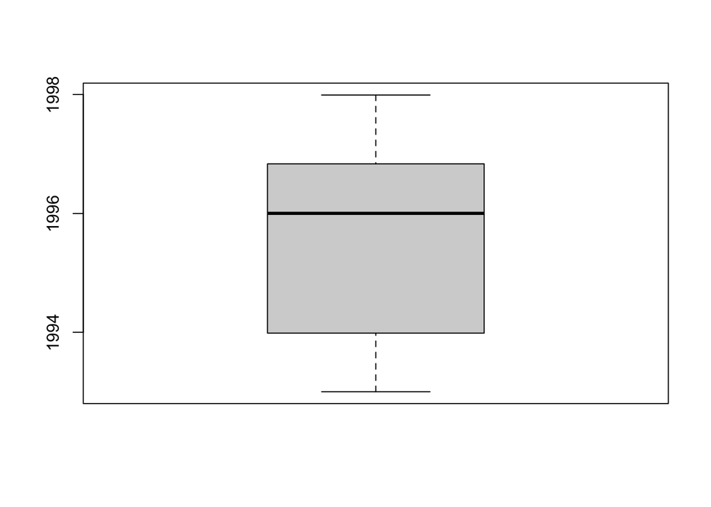

```r
boxplot(account$date)
```

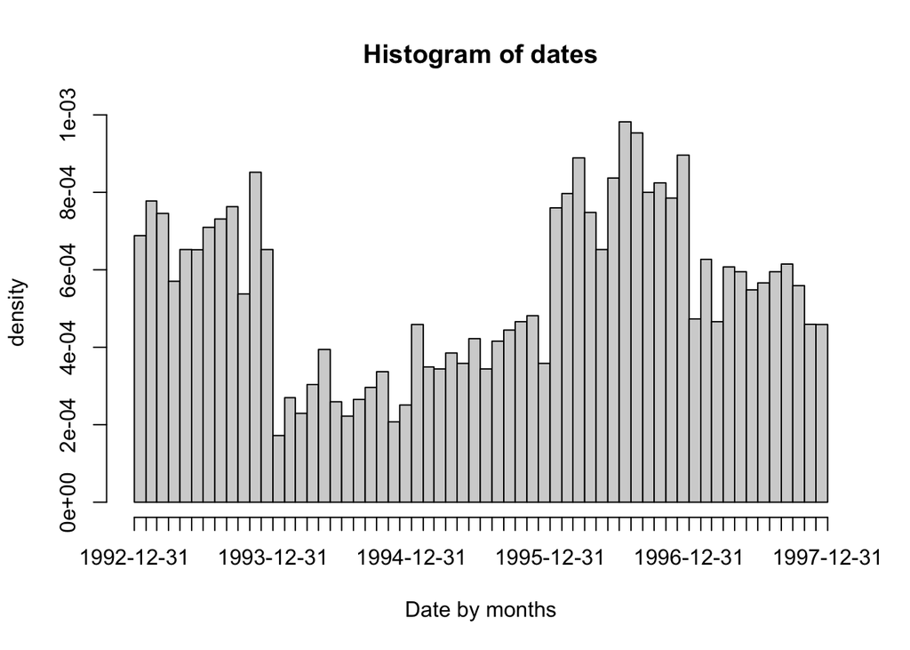

```r
hist(account$date, breaks = "months", xlab="Date by months", ylab = "density", main = "Histogram of dates")
```

## 1.5 Encoding categorical variables

\ indicar a preseça do cartao bancario (ou nao) no client \ consideramos que o client so tem cartao se for o owner da conta

```r
join <- left_join(client_transform, disp_transform, by = "client_id")
client_transform <- join %>%
  mutate(have_card = case_when(
    is.na(type) ~ NA,
    type == "OWNER" ~ 1,
    type == "DISPONENT" ~ 0,
  )) %>%
  select(-type, -disp_id, -account_id)

rm(join)
```

```r
one_hot_encoded <- model.matrix(~ 0 + frequency, data = account_transform)
factor_levels <- levels(account_transform$frequency)
#print(factor_levels)
custom_column_names <- paste("frequency", factor_levels, sep = ": ")
colnames(one_hot_encoded) <- custom_column_names

#print(one_hot_encoded)
account_transform <- account_transform %>%
    cbind(one_hot_encoded) %>%
    select(-frequency)
rm(one_hot_encoded, custom_column_names)
```

```r
one_hot_encoded <- model.matrix(~ 0 + type, data = card_dev_transform)
#print(one_hot_encoded)
factor_levels <- levels(card_dev_transform$type)
#print(factor_levels)
custom_column_names <- paste("type", factor_levels, sep = ": ")
colnames(one_hot_encoded) <- custom_column_names

#print(one_hot_encoded)
card_dev_transform <- card_dev_transform %>%
    cbind(one_hot_encoded) %>%
    select(-type)
rm(one_hot_encoded, factor_levels, custom_column_names)
```

```r
one_hot_encoded <- model.matrix(~ 0 + type, data = disp_transform)
#print(one_hot_encoded)
factor_levels <- levels(disp_transform$type)
#print(factor_levels)
custom_column_names <- paste("type", factor_levels, sep = ": ")
colnames(one_hot_encoded) <- custom_column_names

#print(one_hot_encoded)
disp_transform <- disp_transform %>%
    cbind(one_hot_encoded) %>%
    select(-type)
rm(one_hot_encoded, factor_levels, custom_column_names)
```

```r
one_hot_encoded <- model.matrix(~ 0 + region, data = district_transform)
#print(one_hot_encoded)
factor_levels <- levels(district_transform$region)
#print(factor_levels)
custom_column_names <- paste("region", factor_levels, sep = ": ")
colnames(one_hot_encoded) <- custom_column_names

#print(one_hot_encoded)
district_transform <- district_transform %>%
    cbind(one_hot_encoded) %>%
    select(-region)
rm(one_hot_encoded, factor_levels, custom_column_names)
```

```r
one_hot_encoded <- model.matrix(~ 0 + type, data = trans_dev_transform)
#print(one_hot_encoded)
factor_levels <- levels(trans_dev_transform$type)
#print(factor_levels)

custom_column_names <- paste("type", factor_levels, sep = ": ")
colnames(one_hot_encoded) <- custom_column_names

#print(one_hot_encoded)
trans_dev_transform <- trans_dev_transform %>%
    cbind(one_hot_encoded) %>%
    select(-type)
rm(one_hot_encoded, factor_levels, custom_column_names)


trans_dev_operation <- trans_dev_transform %>%
  select(trans_id, operation)

trans_dev_transform <- trans_dev_transform %>%
  select(-operation)
```

## 1.6 Feature engineering

Ver a ultima transaçao feita antes do loan para saber quanto dinheiro temos no banco antes de fazer a loan

```r
last_trans_per_client <- loan_dev_transform %>%
  left_join(trans_dev_transform,
            by = "account_id",
            suffix = c (".loan", ".trans")
            ) %>%
  group_by(account_id, date.loan) %>%
  filter(date.loan > date.trans) %>%
  slice_max(order_by = date.trans ) %>%
  slice_max(order_by = trans_id) %>%
  ungroup() %>%
  select( "account_id", "balance") %>%
  rename(money_in_account = balance)

loan_dev_transform <- loan_dev_transform %>%
  left_join(last_trans_per_client, by = "account_id")  # ultima transaçao antes da data da loan

rm(last_trans_per_client)
```

Calcular o dia dos anos do cliente (correctamente) Calcular o genero do cliente se o gender for feminino é 1 (sim), se masculino é 0(nao)

```r
client_transform <- client_transform %>%
  mutate(year = as.numeric(substr(birth_number, 1, 2))) %>%
  mutate(month = as.numeric(substr(birth_number, 3, 4))) %>%
  mutate(gender_F = if_else(month > 50, 1, 0)) %>%
  mutate(month = if_else(month > 50, month - 50, month)) %>%
  mutate(day = as.numeric(substr(birth_number, 5, 6))) %>%
  mutate(birth_day = as.Date(paste(paste("19", year, sep=""), month, day, sep = "-"), format = "%Y-%m-%d")) %>%
  select( -year, -month, -day, -birth_number)
```

Calcular a idade do cliente quando fez a loan

```r
disp_temp2 <- disp_transform %>%
  filter(`type: OWNER` == "1") %>%
  select(-`type: DISPONENT`, -`type: OWNER`)

age_loan <- loan_dev_transform %>%
  left_join(disp_temp2,
            by = "account_id",
            ) %>%
   left_join(client_transform,
            by = "client_id",
            ) %>%
    mutate(age = floor(as.numeric(difftime(date, birth_day, units = "days")/ 365.25)) ) %>%
  select(loan_id ,age)

loan_dev_transform <- loan_dev_transform %>%
  left_join(age_loan,
            by= "loan_id")

rm(disp_temp2, age_loan)
```

Juntar tudo o que foi considerado importante para a analise num dataset

```r
district_average_salary <- district_transform %>%
  select(code, `average salary`) %>%
  mutate(district_id = code) %>%
  select(-code)

disp_temp <- disp_transform %>%
  filter(`type: OWNER` == "1") %>%
  select(-`type: DISPONENT`, -`type: OWNER`)

select_columns <- c(names(client_transform), names(loan_dev_transform))
print(select_columns)
```

```
##  [1] "client_id"        "district_id"      "have_card"        "gender_F"
##  [5] "birth_day"        "loan_id"          "account_id"       "date"
##  [9] "amount"           "duration"         "payments"         "status"
## [13] "money_in_account" "age"
```

```r
merge_data <- loan_dev_transform %>%
  left_join(disp_temp,
            by = "account_id",
            ) %>%
   left_join(client_transform,
            by = "client_id",
            ) %>%
  select(select_columns) %>%
  mutate(district_id = as.integer(district_id)) %>%
  left_join(district_average_salary,
            by="district_id")
```

## 1.7 Data splitting

```r
split_data <- function(data, train_fraction = 0.8, seed = 2023) {
  set.seed(seed)
  n_train <- round(train_fraction * nrow(data))
  train_indices <- sample(1:nrow(data), n_train)
  train_data <- data[train_indices, ]
  test_data <- data[-train_indices, ]

  return(list(train = train_data, test = test_data))
}

datasets <- list(account_transform, card_dev_transform, client_transform, disp_transform, district_name, district_transform, loan_dev_transform, trans_dev_operation, trans_dev_transform, merge_data)

names <- list("account_transform", "card_dev_transform", "client_transform", "disp_transform", "district_name_transform", "district_transform", "loan_dev_transform", "trans_dev_operation_transform", "trans_dev_transform", "merge_data")

split_datasets <- lapply(datasets, split_data)

i <- 1

assign_names <- function(split_ds) {
  #cat("ds:", length(split_ds), "\n")
  train_name <- paste(names[[i]], "_train", sep = "")
  test_name <- paste(names[[i]], "_test", sep = "")
  #cat("train_name:", train_name, "\n")
  #cat("test_name:", test_name, "\n")

  assign(train_name, split_ds$train, envir = .GlobalEnv)
  assign(test_name, split_ds$test, envir = .GlobalEnv)

  i <<- i+1
}

new_dataset_name <- lapply(split_datasets, assign_names)

rm(datasets)
```

## 1.8 Feature Scaling

// Feature scaling is a preprocessing step that aims to standardize or normalize the range of independent variables or features of a dataset

Standardization (Z-score normalization)

todo: district_transformation maybe need other thing than on-hot encoding

```r
features <- c(
  'no. of inhabitants', 'no. of municipalities with inhabitants < 499',
  'no. of municipalities with inhabitants 500-1999', 'no. of municipalities with inhabitants 2000-9999',
  'no. of municipalities with inhabitants >10000', 'no. of cities', 'ratio of urban inhabitants',
  'average salary', 'unemploymant rate \'95', 'unemploymant rate \'96',
  'no. of enterpreneurs per 1000 inhabitants', 'no. of commited crimes \'95',
  'no. of commited crimes \'96'
)

district_transform_train[, features] <- scale(district_transform_train[,features])
```

Teste para verificar se a visualização da padronização (z-scale) foi aplicada correctamente.

```r
summary(district_transform_train[, features])
```

```
##  no. of inhabitants no. of municipalities with inhabitants < 499
##  Min.   :-1.2772    Min.   :-1.4394
##  1st Qu.:-0.5753    1st Qu.:-0.7465
##  Median :-0.2121    Median :-0.1768
##  Mean   : 0.0000    Mean   : 0.0000
##  3rd Qu.: 0.2819    3rd Qu.: 0.5468
##  Max.   : 4.3249    Max.   : 3.2105
##  no. of municipalities with inhabitants 500-1999
##  Min.   :-1.81767
##  1st Qu.:-0.61317
##  Median :-0.04857
##  Mean   : 0.00000
##  3rd Qu.: 0.44076
##  Max.   : 3.45199
##  no. of municipalities with inhabitants 2000-9999
##  Min.   :-1.6093
##  1st Qu.:-0.5248
##  Median :-0.1181
##  Mean   : 0.0000
##  3rd Qu.: 0.2886
##  Max.   : 3.8135
##  no. of municipalities with inhabitants >10000 no. of cities
##  Min.   :-1.6923                               Min.   :-2.1625
##  1st Qu.:-0.7470                               1st Qu.:-0.5373
##  Median : 0.1982                               Median :-0.1311
##  Mean   : 0.0000                               Mean   : 0.0000
##  3rd Qu.: 0.1982                               3rd Qu.: 0.6815
##  Max.   : 3.0339                               Max.   : 1.9004
##  ratio of urban inhabitants average salary    unemploymant rate '95
##  Min.   :-1.8546            Min.   :-1.3530   Min.   :-1.67422
##  1st Qu.:-0.7398            1st Qu.:-0.7206   1st Qu.:-0.81753
##  Median :-0.1526            Median :-0.2389   Median :-0.07447
##  Mean   : 0.0000            Mean   : 0.0000   Mean   : 0.00000
##  3rd Qu.: 0.7075            3rd Qu.: 0.5082   3rd Qu.: 0.34267
##  Max.   : 2.1777            Max.   : 2.7837   Max.   : 2.44626
##  unemploymant rate '96 no. of enterpreneurs per 1000 inhabitants
##  Min.   :-1.7672       Min.   :-2.1807
##  1st Qu.:-0.7691       1st Qu.:-0.6593
##  Median :-0.1176       Median :-0.1730
##  Mean   : 0.0000       Mean   : 0.0000
##  3rd Qu.: 0.4127       3rd Qu.: 0.6269
##  Max.   : 2.8506       Max.   : 2.4620
##  no. of commited crimes '95 no. of commited crimes '96
##  Min.   :-0.9512            Min.   :-0.9483
##  1st Qu.:-0.5530            1st Qu.:-0.5571
##  Median :-0.2939            Median :-0.2778
##  Mean   : 0.0000            Mean   : 0.0000
##  3rd Qu.: 0.1979            3rd Qu.: 0.1894
##  Max.   : 4.4946            Max.   : 4.5501
```

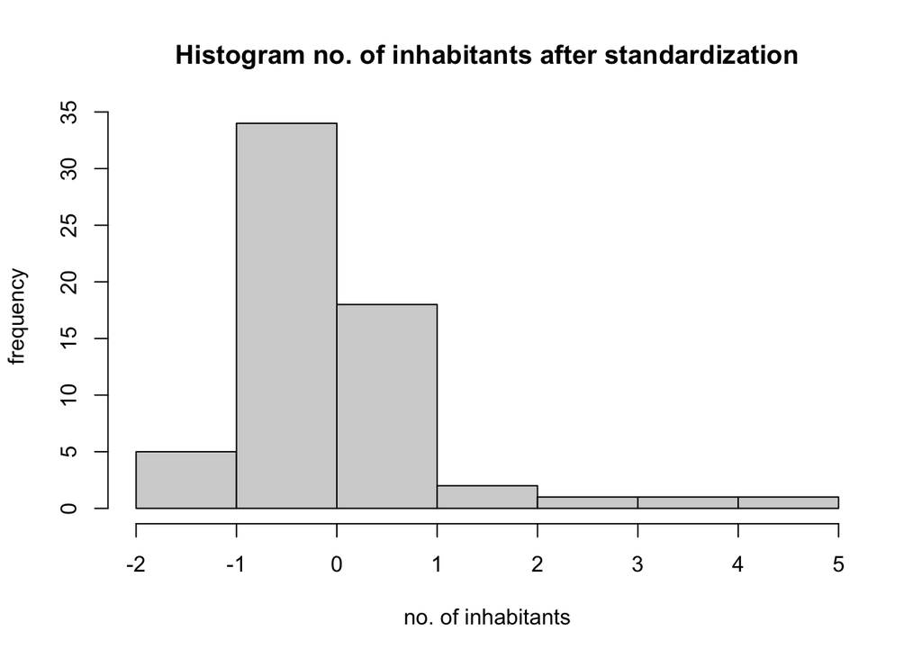

```r
#class(district_transform_train[, features[1]])


# Após a padronização
hist(district_transform_train[, features[1]],
     main = "Histogram no. of inhabitants after standardization",
     xlab = "no. of inhabitants",
     ylab = "frequency"
     )
```

```r
rm(features)
```

```r
features_loan <- c(
  'amount',
  'duration',
  'payments',
  'money_in_account',
  'age'
)

loan_dev_transform_train[, features_loan] <- scale(loan_dev_transform_train[, features_loan])
```

Teste para verificar se a visualização da padronização (z-scale) foi aplicada correctamente.

```r
summary(loan_dev_transform_train[, features_loan])
```

```
##      amount           duration           payments       money_in_account
##  Min.   :-1.3446   Min.   :-1.42926   Min.   :-1.6968   Min.   :-1.6064
##  1st Qu.:-0.7884   1st Qu.:-0.72405   1st Qu.:-0.7959   1st Qu.:-0.7481
##  Median :-0.2417   Median :-0.01884   Median :-0.1183   Median :-0.1601
##  Mean   : 0.0000   Mean   : 0.00000   Mean   : 0.0000   Mean   : 0.0000
##  3rd Qu.: 0.5495   3rd Qu.: 0.68637   3rd Qu.: 0.7943   3rd Qu.: 0.4361
##  Max.   : 3.7100   Max.   : 1.39158   Max.   : 2.5140   Max.   : 3.1161
##       age
##  Min.   :-1.828580
##  1st Qu.:-0.878323
##  Median :-0.007254
##  Mean   : 0.000000
##  3rd Qu.: 0.784627
##  Max.   : 1.893260
```

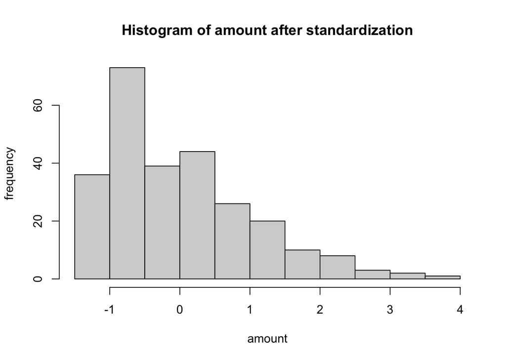

```r
#class(loan_dev_transform_train[[features_loan[1]]])

hist(loan_dev_transform_train[[features_loan[1]]],
     main = "Histogram of amount after standardization",
     xlab = "amount",
     ylab = "frequency"
)
```

```r
rm(features_loan)
```

```r
features_trans <- c(
  'amount',
  'balance'
)

trans_dev_transform_train[, features_trans] <- scale(trans_dev_transform_train[, features_trans])
```

Teste para verificar se a visualização da padronização (z-scale) foi aplicada correctamente.

```r
summary(trans_dev_transform_train[, features_trans])
```

```
##      amount           balance
##  Min.   :-0.6171   Min.   :-2.4279
##  1st Qu.:-0.6033   1st Qu.:-0.6787
##  Median :-0.4050   Median :-0.2462
##  Mean   : 0.0000   Mean   : 0.0000
##  3rd Qu.: 0.0883   3rd Qu.: 0.4486
##  Max.   : 7.9653   Max.   : 8.0289
```

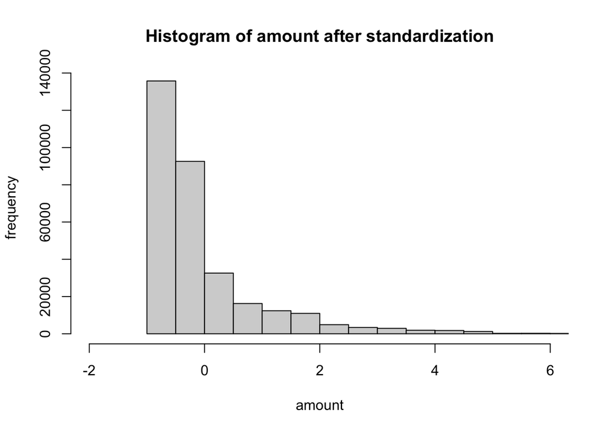

```r
#class(trans_dev_transform_train[[features_trans[1]]])

hist(trans_dev_transform_train[[features_trans[1]]],
     main = "Histogram of amount after standardization",
     xlab = "amount",
     ylab = "frequency",
     xlim = c(-2, 6)
)
```

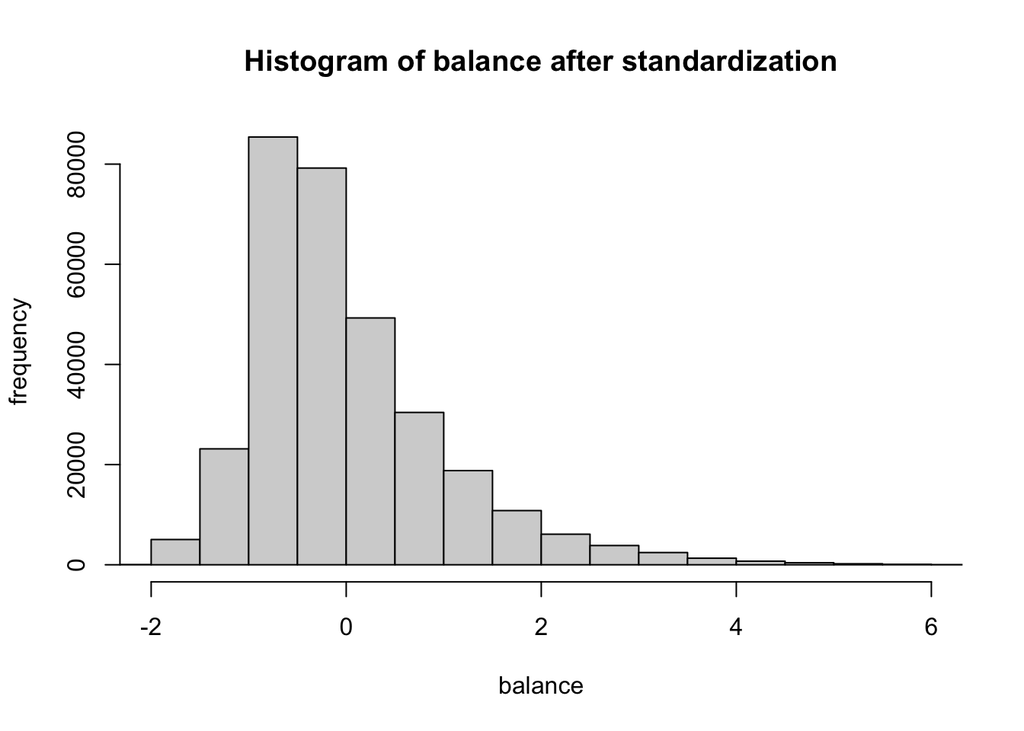

```r
hist(trans_dev_transform_train[[features_trans[2]]],
     main = "Histogram of balance after standardization",
     xlab = "balance",
     ylab = "frequency",
     xlim = c(-2, 6)
)
```

```r
rm(features_loan)
```

```r
features_merge <- c(
  'amount',
  'duration',
  'payments',
  'money_in_account',
  'age',
  'average salary'
)

merge_data_train[, features_merge] <- scale(merge_data_train[, features_merge])


mean_values <- colMeans(merge_data_train[, features_merge], na.rm = TRUE)
standerd_deviation_values <- apply(merge_data_train[, features_merge], 2, sd, na.rm = TRUE)

merge_data_test[, features_merge] <- scale(merge_data_test[, features_merge], center = mean_values, scale = standerd_deviation_values)

rm(features_merge, mean_values, standerd_deviation_values)
```

## 1.9 Save

```r
save(account_transform, file="Rdata/account.Rdata")
save(card_dev_transform, file="Rdata/card_dev.Rdata")
save(client_transform, file="Rdata/client.Rdata")
save(disp_transform, file="Rdata/disp.Rdata")
save(district_transform, file="Rdata/district.RData")
save(loan_dev_transform, file="Rdata/loan_dev.Rdata")
save(trans_dev_transform, file="Rdata/trans_dev.Rdata")
save(trans_dev_operation, file="Rdata/trans_dev_operation.Rdata")
save(district_name, file="Rdata/district_name.Rdata")
save(merge_data, file="Rdata/merge_data.Rdata")


#save train datasets
save(account_transform_train, file="Rdata/train/account_train.Rdata")
save(card_dev_transform_train, file="Rdata/train/card_dev_train.Rdata")
save(client_transform_train, file="Rdata/train/client_train.Rdata")
save(disp_transform_train, file="Rdata/train/disp_train.Rdata")
save(district_transform_train, file="Rdata/train/district_train.RData")
save(loan_dev_transform_train, file="Rdata/train/loan_dev_train.Rdata")
save(trans_dev_transform_train, file="Rdata/train/trans_dev_train.Rdata")
save(trans_dev_operation_transform_train, file="Rdata/train/trans_dev_operation_train.Rdata")
save(district_name_transform_train, file="Rdata/train/district_name_train.Rdata")
save(merge_data_train, file="Rdata/train/merge_data_train.Rdata")


#save test dataset
# save(account_transform_test, file="Rdata/test/account_test.Rdata")
# save(card_dev_transform_test, file="Rdata/test/card_dev_test.Rdata")
# save(client_transform_test, file="Rdata/test/client_test.Rdata")
# save(disp_transform_test, file="Rdata/test/disp_test.Rdata")
# save(district_transform_test, file="Rdata/test/district_test.RData")
# save(loan_dev_transform_test, file="Rdata/test/loan_dev_test.Rdata")
# save(trans_dev_transform_test, file="Rdata/test/trans_dev_test.Rdata")
# save(trans_dev_operation_transform_test, file="Rdata/test/trans_dev_operation_test.Rdata")
# save(district_name_transform_test, file="Rdata/test/district_name_test.Rdata")
save(merge_data_test, file="Rdata/test/merge_data_test.Rdata")


#load()
```